# Team Project1

复旦第三区交通委

2019年3月26日

## 准备工作

读取西安地区运动健身数据，并存入tuangou。

```r
library(openxlsx)
# 读取‘西安地区运动健身数据.xlsx'的数据
tuangou = read.xlsx('/Users/zhaoyaying/Desktop/R/data_mining/team1/西安地区运动健身数据.xlsx', sheet = 1)
```

## 数据预处理

健身房团购的数据中，存在缺失的数据列有“评分”，“评论数”，“规格”，“团购价格”，“团购内容”，“有效期”，“可用时间”和“预约说明”。有一些数据“评分”，“评论数”，“规格”，“价格”，“内容”全部缺失，很明显这样的“五无”数据应该删去，一共有 64 条这样的数据。将修改过后的表格储存在tuangou1变量中。

```r
tuangou1 = tuangou
# 删去“五无”数据
tuangou1 = tuangou[!(is.na(tuangou$评分) & is.na(tuangou$评论数) & is.na(tuangou$规格) & is.na(tuangou$`团购价格(元)`) & is.na(tuangou$团购内容)), ]
```

统计每行数据有多少缺失值

```r
library(ggplot2)
tuangou1$缺失数 <- 0
for(i in 1:length(tuangou1$缺失数))
{
  tuangou1[i, ]$缺失数 <- sum(is.na(tuangou1[i, ]))
}
# ggplot(data=tuangou1,mapping=aes(x=factor(缺失数), y=log(团购数)), fill=缺失数)+
#   geom_boxplot(alpha=0.9)+
#   theme(text = element_text(family='STKaiti'))
```

仔细观察数据，我们可以看出“规格”，“团购内容”，“可用时间”，“预约说明”属于类别型变量，规格的缺失值可以使用“1次”。在后续变量的提取中我们可以把缺失值分类到“其他”，所以暂时不需要处理。

其余列都属于数值型变量。我们将“评分”与“评论数”的缺失值设为其他有效数据的均值。

```r
# 规格的缺失值设置为“1次”
tuangou1[is.na(tuangou1$规格), 5] = '1次'
# 评分的缺失值设置为其余评分的均值
tuangou1[is.na(tuangou1$评分), 3] = mean(tuangou1$评分, na.rm = T)
# 评论数的缺失值设置为其余评论数的均值
tuangou1[is.na(tuangou1$评论数), 4] = mean(tuangou1$评论数, na.rm = T)

# # 评论数的缺失值根据其下一行的数据设置
# tuangou1[1517, 4] = 0
# line <- is.na(tuangou1$评论数)
# n <- 1517
# for(i in 1:n-1)
# {
#   if(line[n-i]==TRUE)
#   {
#     tuangou1[n-i, 4] = tuangou1[n-i+1, 4]
#   }
# }
```

查看标题、团购内容、温馨提示里面出现频次比较多的几个词

```r
library(jiebaR)
fenci <- function(seq){
  # 使用qseg类型分词，并把结果保存到对象seg中
  seq <- qseg[seq]
  # 统计词频
  seq <- table(seq)
  # 去除数字
  seq <- seq[!grepl('[0-9]+',names(seq))]
  # 降序排序，并提取出现次数最多的前50个词语
  seq <- sort(seq, decreasing = TRUE)
  # print(seq)
}                                          #编写分词函数

title <- fenci(tuangou1$标题)
content <- fenci(tuangou1$团购内容)
note <- fenci(tuangou1$温馨提示)                       #使用分词函数查看文本数据中的高频词出现次数
```

```r
library(wordcloud2)
wordcloud2(title, size = 2, fontFamily = "微软雅黑", color = "random-light", backgroundColor = "grey")
```

[interactive chart not shown]

```r
wordcloud2(content, size = 2, fontFamily = "微软雅黑", color = "random-light", backgroundColor = "grey")
```

[interactive chart not shown]

```r
wordcloud2(note, size = 2, fontFamily = "微软雅黑", color = "random-light", backgroundColor = "grey")
```

[interactive chart not shown]

把一个团购项目的使用次数和权限分为几个属性（是否是月卡，年卡，季卡，周卡），如果都不是，则按照其规格属性里的’节，次，份’来计数，使用正则表达式提取出数字。其他（样本量不大）用“小时”，“课”，“期”计量的样本都看作是一次（我们假设，这些样本一般属于“几小时的体育运动包场”，“一课舞蹈课”，“一期培训班”，可整体地看作一次消费）。月卡、季卡、年卡、周卡列都为0则代表是计次（这里没有考虑月卡中也必须计次的情况了）。月卡、年卡、季卡、周卡的消费项目在“次数”属性上一定为0。

```r
library(stringr)
# 对月卡、年卡、季卡、周卡进行哑变量处理
tuangou1$月卡 = as.integer(grepl('月卡', tuangou1$团购内容)|grepl('月', tuangou1$团购内容))
tuangou1$年卡 = as.integer(grepl('年卡', tuangou1$团购内容)|grepl('年', tuangou1$团购内容))
tuangou1$季卡 = as.integer(grepl('季卡', tuangou1$团购内容) | grepl('季度卡', tuangou1$团购内容))
tuangou1$周卡 = as.integer(grepl('周卡', tuangou1$团购内容))
# 新建“次数”列。当不属于以上四类时保存次数，以上四类卡的次数设置为0
# “次数”默认值设为1
tuangou1$次数 = rep(1,length(tuangou1$标题))
# 正则表达式匹配"[0-9]+[次,节,份]"
re = str_extract_all(tuangou1[grepl('次',tuangou1$规格) | grepl('节',tuangou1$规格) | grepl('份',tuangou1$规格),5], "[0-9]+[次,节,份]")
# 把次、节、份扔掉
tuangou1[grepl('次', tuangou1$规格) | grepl('节', tuangou1$规格) | grepl('份',tuangou1$规格), 17] = as.integer(substring(re, 1, nchar(re)-1))
# 月卡、年卡、季卡、周卡的“次数”设置为0
tuangou1[tuangou1$月卡 == 1 | tuangou1$年卡 == 1 | tuangou1$季卡 == 1 | tuangou1$周卡 == 1, 17] = 0
```

对项目进行简单分类，分为了桌球，瑜伽，舞蹈，健身和其他。主要的依据是“团购内容”里是否提到了对应的项目名称（第一轮标注）；为了解决有些项目内容里只写了“月卡”，“代金券”这样的内容，所以我们把第一轮标注中标为“其他”而且内容里只有“月卡”，“代金券”或者内容直接为NA的样本标记为其店名中出现的项目（比如在“复旦台球馆”就标记为台球）。

```r
# item为团购项目的项目分类。默认值设为'其他'
item = rep('其他', length(tuangou1$标题))
# 将“团购内容”中出现黑八、斯诺克、黑8、台球关键词的团购项目均标记为'桌球'
item[grepl('桌球', tuangou1$团购内容) | grepl('黑八', tuangou1$团购内容) | grepl('斯诺克', tuangou1$团购内容) | grepl('黑8', tuangou1$团购内容) | grepl('台球', tuangou1$团购内容)] = '桌球'
# 将“团购内容”中出现瑜伽关键词的团购项目均标记为'瑜伽'
item[grepl('瑜伽', tuangou1$团购内容)] = '瑜伽'
# 将“团购内容”中出现舞关键词的团购项目均标记为'舞蹈'
item[grepl('舞', tuangou1$团购内容)] = '舞蹈'
# 将“团购内容”中出现健身关键词的团购项目均标记为'健身'
item[grepl('健身', tuangou1$团购内容)] = '健身'
# 对于item中标为“其他”，且“团购内容”里只有“月卡”，“代金券”或者是NA的样本：
# 标题中出现台球、桌球关键词的团购项目均标记为'桌球'
item[item == '其他' & (grepl('台球', tuangou1$标题) | grepl('桌球', tuangou1$标题))] = '桌球'
# 标题中出现瑜伽关键词的团购项目均标记为'瑜伽'
item[item == '其他' & grepl('瑜伽', tuangou1$标题)] = '瑜伽'
# 标题中出现舞关键词的团购项目均标记为'舞蹈'
item[item == '其他' & grepl('舞', tuangou1$标题)] = '舞蹈'
# 标题中出现健身关键词的团购项目均标记为'健身'
item[item == '其他' & grepl('健身', tuangou1$标题)] = '健身'
tuangou1$项目 = item
# ggplot(data=tuangou1,mapping=aes(x=项目,y=log(团购数),fill=项目))+
#   geom_boxplot(alpha=0.6)+
#   theme(text = element_text(family='STKaiti'))
```

对于“价格”列，因为价格不可能设置为0，所以把缺失值的价格设为当前运动（项目）类别的平均数。（或者中位数？）

```r
for (ind in 1:length(tuangou1$标题)){
  if(is.na(tuangou1$`团购价格(元)`[ind])){
    # 把缺失值的价格设为当前运动（项目）类别的平均数
    tuangou1$`团购价格(元)`[ind] = mean(tuangou1$`团购价格(元)`[item == item[ind]], na.rm = T)
  }
}
```

“有效期”属于区间型变量，可以通过对于字符串的处理转化为数值型变量，进一步得到有效期多长。缺失值取众数，也就是说假设缺失值一般就表明其有效期就是一般传统的长度，其起始年份也就是团购项目最多的那年。

```r
# 将“有效期”列的年,月,日替换为'/'，再将'至'前后分为两个字符串
valid_date = strsplit(gsub('[年,月,日]', '/', tuangou1[!is.na(tuangou1$有效期), 8]), '至')
# 将所有日期放进一个vector中
valid_date = as.vector(unlist(valid_date))
# valid_date的奇数位均为开始年月日，存入begin变量
begin = as.Date(valid_date[seq(1, 2945, 2)])
# valid_date的偶数位均为结束年月日，存入end变量
end = as.Date(valid_date[seq(2, 2946, 2)])
# 将end与begin相减，得到有效期的时长diffD
diffD = as.integer(end - begin)
# 将begin的前四位数字提取出来，作为起始年份beginYear
beginYear = as.integer(substring(begin,1,4))
# 新增“有效天数”列，将有“有效期”的数据附上diffD
tuangou1$有效天数[!is.na(tuangou1$有效期)] = diffD
# 新增“起始年份”列，将有“有效期”的数据附上beginYear
tuangou1$起始年份[!is.na(tuangou1$有效期)] = beginYear
# 缺失“有效期”的数据，“有效天数”以及“起始年份”均取众数
# 用table()得diffD以及beginYear各元素的频数
diffD = table(diffD)
beginYear = table(beginYear)
# 将diffD中频数最多的项(有效期的众数)赋给有效期为NA的项目的“有效天数”。beginYear同理。
tuangou1$有效天数[is.na(tuangou1$有效期)] = as.integer(names(diffD)[diffD == max(diffD)])
tuangou1$起始年份[is.na(tuangou1$有效期)] = as.integer(names(beginYear)[beginYear == max(beginYear)])

# ggplot(data=tuangou1,mapping=aes(x=guige,y=log(团购数),fill=guige))+
#   geom_boxplot(alpha=0.6)+
#   theme(text = element_text(family='STKaiti'))
```

## 提取衍生变量

从原始数据的“可用时间”、“预约说明”、“团购内容”以及“温馨提示”中提取以下二元离散变量：是否节假日通用，是否无需预约，是否有礼品，是否仅限本人，是否有温馨提示，是否仅体验。

## 因变量

首先对因变量团购数进行分析，绘制直方图。显然，对数团购量更适合分析。由于很多项目没人买，即团购数是0，所以将这些值的对数团购数设为-1。

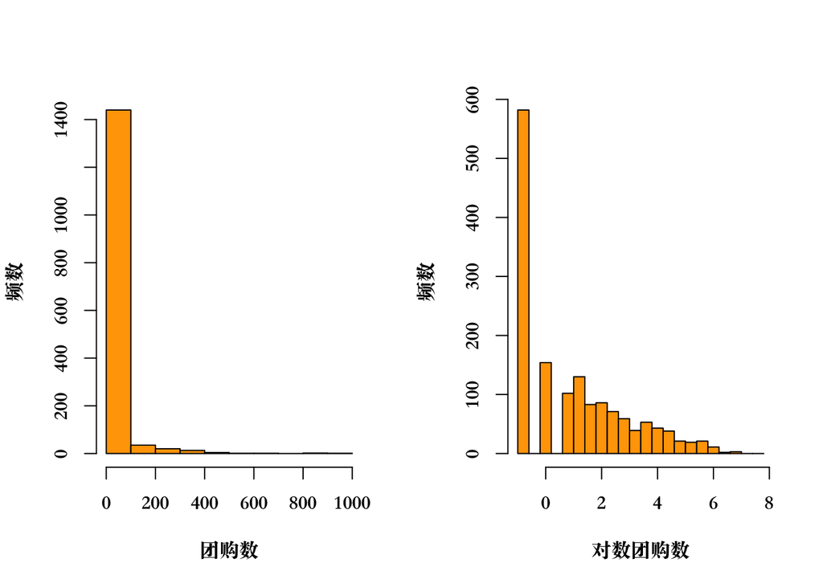

```r
# 设置绘图格式
par(family = 'STSongti-SC-Black', mfrow = c(1,2))
# 绘制团购数的直方图
hist(tuangou1$团购数, main = " ",col = "orange", xlab = "团购数",ylab = "频数")
tuangou1$tgs_log = log(tuangou1$团购数)
# 将团购数是0的项目的对数团购数设为-1
tuangou1$tgs_log[tuangou1$tgs_log == -Inf] = -1
# 绘制对数团购数的直方图
hist(tuangou1$tgs_log, main = " ", breaks = seq(-1,8,0.4), col = "orange", xlab="对数团购数",ylab="频数")
```

## 评分

首先观察评分对于log团购数的影响（基准值设定可以再修改）：

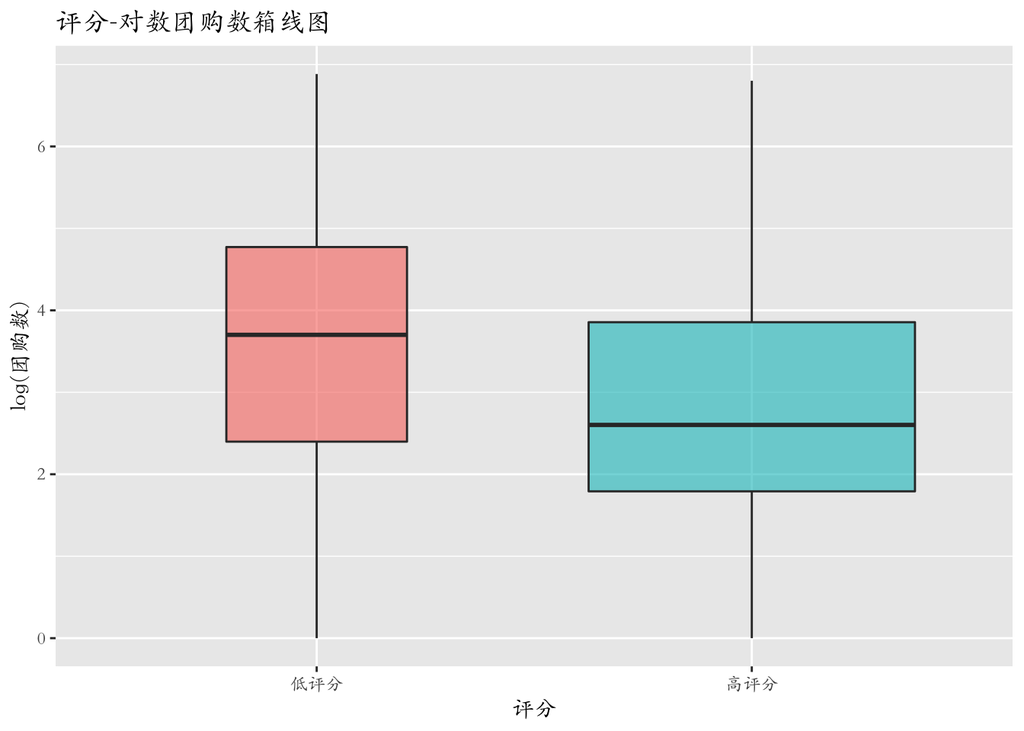

```r
#set the baseline 设定区分高低评分的基准值
rank_base = 4.6
#提取出评分数据没有缺失的数据
tuangou_temp = tuangou[!is.na(tuangou$评分), ]
#根据baseline来划分高低评分
credit = rep('低评分',length(tuangou_temp$标题))
credit[tuangou_temp$评分 >= rank_base] = '高评分'
#作图
ggplot(data = tuangou_temp, mapping = aes(x = credit, y = log(团购数), fill = credit))+
  geom_boxplot(alpha = 0.6, varwidth=T) +
  labs(x = '评分', title = '评分-对数团购数箱线图') +
  theme(text = element_text(family='STKaiti')) +
  scale_fill_discrete(guide = FALSE)
```

通过观察原来数据（因为我们对缺失值都取了同样的值，可能对箱线图有很大的影响,为了能在描述性分析中尽量去寻找到数据本身提供的信息所以使用了没有缺失评分的数据来进行分析），我们发现其实高低评分对团购数的影响和我们预期相反，高评分的反倒处于相对较低的水平，我们查看原来评分的中位数，发现是5，说明可能我们的样本对于评分的衡量其实不是很准确（评分其实本身会受到团购数的影响，因为消费了才可以评分，如果只有一两个人评分，很有可能都是5分，但这不具有说服力，但是如果团购的人数多，可能会因为个人的喜好不同导致评分比较低，所以虽然评分能反映出该项目的好坏，但不一定能直接影响到团购数本身，两者之间存在复杂的相互影响）。

## 评论数

接下来观察评论数对于团购数的影响，我们发现评论数的中位数是0（1031个样本无评论），说明大多数团购项目都没有评论，所以通过是否有评论数来划分样本：

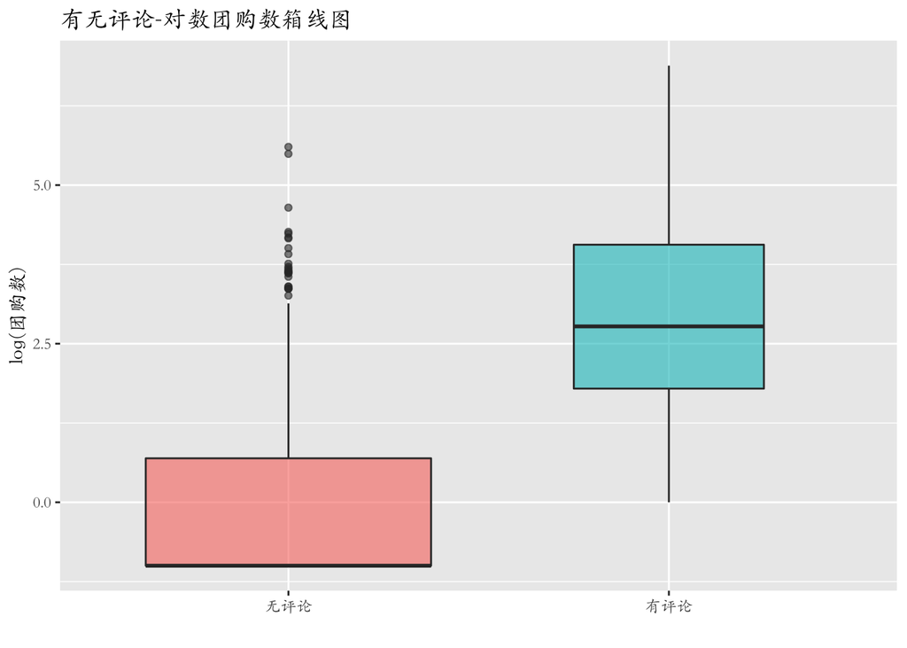

```r
# # set the baseline
# rank_base = 0
# comm用于储存对应样本是否有人评论过，无评论为原始评论缺失
comm = rep('无评论',length(tuangou$标题))
comm[!is.na(tuangou$评论数)] = '有评论'
# 将原始数据中团购数是0的项目的对数团购数设为-1
tuangou$tgs_log = log(tuangou$团购数)
tuangou$tgs_log[tuangou$tgs_log == -Inf] = -1
# 作图
ggplot(data = tuangou, mapping = aes(x = factor(comm), y = tgs_log, fill = comm)) +
  #stat_boxplot(geom = "errorbar", width = 0.3)+
  geom_boxplot(alpha = 0.6, varwidth = T) +
  labs(x = ' ', y = 'log(团购数)', title = '有无评论-对数团购数箱线图') +
  theme(text = element_text(family = 'STKaiti')) +
  scale_fill_discrete(guide = FALSE)
```

很明显有评论的团购项目能反映出其团购数也相对来说更多，从两个方面解释，一是一个团购项目的购买量多了才更可能有人愿意去评论，团购数越多说明这个项目相对来说质量还不错，所以也会让人更愿意去评论；二是代表了有评论的团购项目更吸引消费者，因为有之前的消费者的经验会让后来的消费者有所了解，更加放心购买（不考虑差评的话）。

## 评论数*评分 为了惩罚评论少且评分高的项目，接下来我们考察评论数*评分对于团购数的影响。

```r
# cs用于储存评论数 * 评分的值
cs = tuangou$评论数 * tuangou$评分
summary(cs)
```

```
##    Min. 1st Qu.  Median    Mean 3rd Qu.    Max.    NA's
##    1.00    5.00   10.00   28.68   25.15  404.80    1095
```

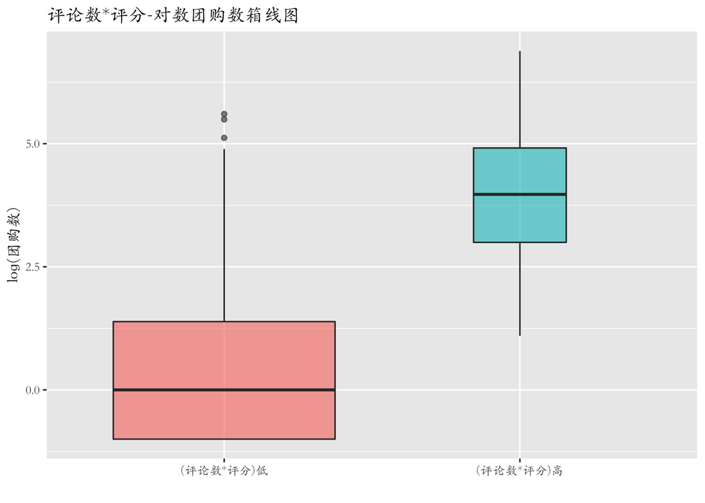

```r
# 查看cs得10为其中位数，设置为bar
cs_bar = 10
cs_divide = rep('(评论数*评分)低', length(cs))
cs_divide[cs > cs_bar] = '(评论数*评分)高'
# 作图
ggplot(data = tuangou, mapping = aes(x = cs_divide, y = tgs_log, fill = cs_divide)) +
  geom_boxplot(alpha = 0.6, varwidth = T) +
  labs(x = ' ', y = 'log(团购数)', y = 'log(团购数)', title = '评论数*评分-对数团购数箱线图') +
  theme(text = element_text(family = 'STKaiti')) +
  scale_fill_discrete(guide = FALSE)
```

考察原始数据，我们发现，使用评论数*评分变量，对少评论数且评分高的项目进行惩罚后，明显看到（评论数*评分）高的项目的团购数远大于（评论数*评分）低的项目。说明我们使用评论数*评分的变量来描述性分析团购数有一定合理性。

## 计次方式

观察月卡，季卡，周卡，年卡，计次等不同的消费计次方式对对数团购数的影响：

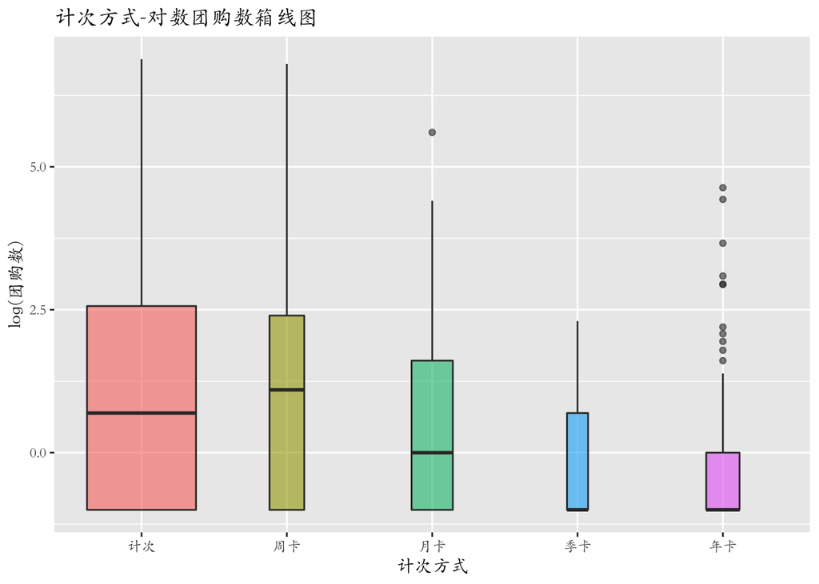

```r
# costWay用来储存对应样本的计费方式，分为计次和办卡（又分为四种）
costWay = rep('计次',length(tuangou1$标题))
costWay[tuangou1$月卡 == 1] = '月卡'
costWay[tuangou1$季卡 == 1] = '季卡'
costWay[tuangou1$周卡 == 1] = '周卡'
costWay[tuangou1$年卡 == 1] = '年卡'
costWay = factor(costWay, levels = c("计次", "周卡", "月卡", "季卡", "年卡"))
# 作图
ggplot(data = tuangou1, mapping = aes(x = costWay, y = tgs_log, fill = costWay)) +
  geom_boxplot(alpha = 0.6, varwidth = T) +
  labs(x = '计次方式', y = 'log(团购数)', title = '计次方式-对数团购数箱线图') +
  theme(text = element_text(family = 'STKaiti')) +
  scale_fill_discrete(guide = FALSE)
```

观察箱线图可以发现，年卡和季卡这样长时间的团购项目人数少很多，说明相对而言大家更喜欢团购一些短期能消费完的项目，其实不光是团购，很多消费都有这样的特点，毕竟预定了的长期消费可能会有更多不确定因素，年卡，季卡一般会是很熟悉这家店的老客户去消费，所以比较少，但同时方差也比较小，因为各个团购项目针对人群相对少且稳定，而且月卡周卡和计次项目同一消费者可能在一段时间内多次购买，而年卡季卡不太可能。

而月卡周卡和次卡相对而言更受欢迎，因为时间比较短，方便大家随时购买，也会存在一个消费者多次购买的情况，其中整体而言周卡更受欢迎，既免去了计次的麻烦，又不会时限太长。同时这几类中的对数团购数方差也更大（箱子高度看出），因为这样的类别里活动会更加五花八门，其他属性的差异也会增大，导致因变量也差异增大。

## 项目

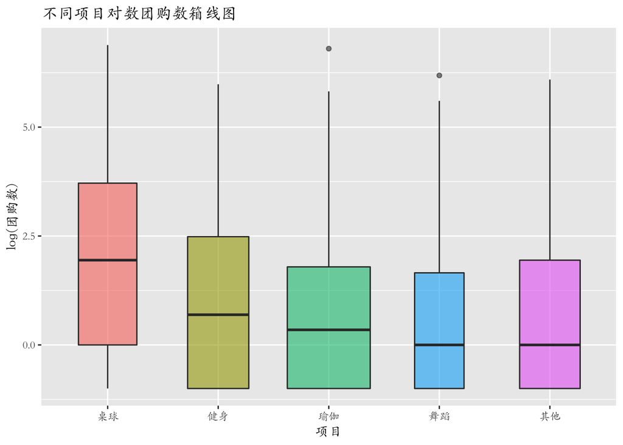

```r
# 调整“项目”的顺序
tuangou1$项目 = factor(tuangou1$项目, levels = c("桌球", "健身", "瑜伽", "舞蹈", "其他"))
ggplot(data = tuangou1, mapping = aes(x = 项目, y = tgs_log, fill = 项目)) +
  geom_boxplot(alpha = 0.6, varwidth = T) +
  labs(x = '项目',y = 'log(团购数)', title = '不同项目对数团购数箱线图') +
  theme(text = element_text(family = 'STKaiti')) +
  scale_fill_discrete(guide = FALSE)
```

此箱线图在一定程度上体现了不同项目的受欢迎程度，相对而言桌球要更受欢迎，团购量要更多，说明大家更喜欢团购桌球这样的项目（可能是相对其他项目来说包场打台球比不团购直接去计时划算的原因），而两大主流健身和瑜伽的团购量也相对而言稍微高于舞蹈和其他项目。

## 有效期

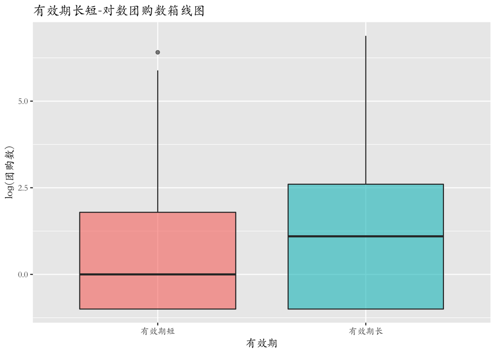

```r
# set the baseline
base = 456   #此基准值是数据的中位数
# 建立days变量，对tuangou1进行有效期短或长的分类
days = rep('有效期短', length(tuangou1$标题))
days[tuangou1$有效天数 > base] = '有效期长'
ggplot(data = tuangou1, mapping = aes(x = days, y = tgs_log, fill = days)) +
  geom_boxplot(alpha = 0.6, varwidth = T) +
  labs(x = '有效期', y = 'log(团购数)', title = '有效期长短-对数团购数箱线图') +
  theme(text = element_text(family = 'STKaiti')) +
  scale_fill_discrete(guide = FALSE)
```

箱线图符合我们的预期，有效期长的团购量更多，因为可以有更多的自由选择使用的时间。

## 起始年份

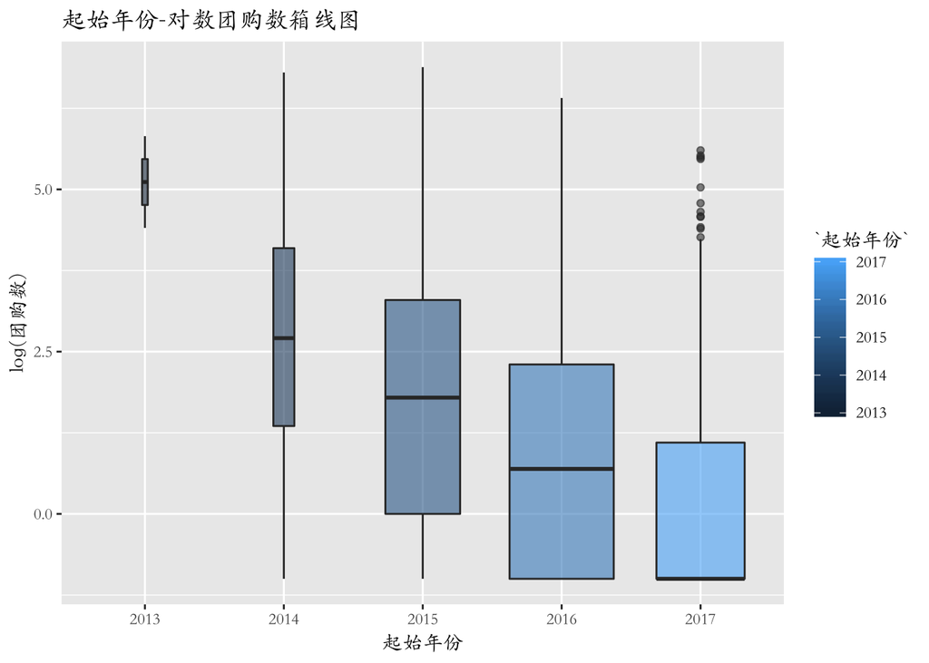

```r
ggplot(data = tuangou1, mapping = aes(x = factor(起始年份), y = tgs_log, fill = 起始年份)) +
  geom_boxplot(alpha = 0.6, varwidth = T) +
  labs(x = '起始年份', y = 'log(团购数)', title = '起始年份-对数团购数箱线图') +
  theme(text = element_text(family = 'STKaiti'))
```

出现这样现象的原因可能是两种：1.时间越早的项目其在平台上出售的时间就更长，也就更可能被更多人购买，比如2017年很多项目其实都还没有人购买，可能是刚登陆平台的原因；2.考虑2013到2015年这段时间，其实在这个时间段登陆平台的项目都有足够的时间供消费者选择，但是仍旧有下降趋势，可能是因为数据量的原因，从箱子宽度可以看出每年新登陆平台的团购项目是在增加的，因为这些健身馆也越开越多，提供了多种多样的项目，而在这三年来相对而言消费者总数是一定的，所以更多的项目分散了消费，每个项目的团购数就变少了。

## 节假日可用

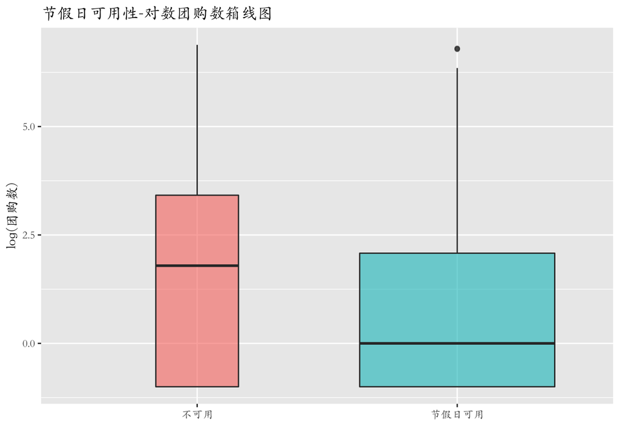

```r
# 建立av变量，对tuangou1进行节假日是否可用的分类
av = rep('不可用',length(tuangou1$标题))
av[tuangou1$节假日通用 == 1] = '节假日可用'
ggplot(data = tuangou1, mapping = aes(x = av, y = tgs_log, fill = av)) +
  geom_boxplot(alpha = 0.6, varwidth = T) +
  labs(x = ' ', y = 'log(团购数)', title = '节假日可用性-对数团购数箱线图') +
  theme(text = element_text(family = 'STKaiti')) +
  scale_fill_discrete(guide = FALSE)
```

这样的结果应该也可以归结到样本数的问题上，因为现在很多团购项目都是节假日可用的了，所以项目多分散了消费，每个项目的团购量相对较少（类似上一部分的解释）。

## 预约

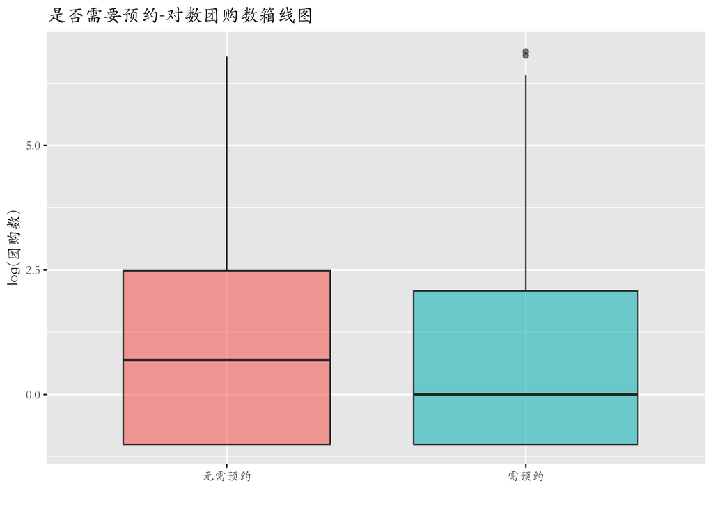

```r
# 建立res变量，对tuangou1进行是否需预约的分类
res = rep('需预约', length(tuangou1$标题))
res[tuangou1$无需预约 == 1] = '无需预约'
ggplot(data = tuangou1, mapping = aes(x = res, y = tgs_log, fill = res)) +
  geom_boxplot(alpha = 0.6, varwidth = T) +
  labs(x = ' ', y = 'log(团购数)', title = '是否需要预约-对数团购数箱线图') +
  theme(text = element_text(family = 'STKaiti')) +
  scale_fill_discrete(guide = FALSE)
```

通过观察箱子的宽度我们可以看出，在这样的划分里，两类样本相对均匀，我们得到的结果也符合我们的预期，因为无需预约直接用的团购项目更加自由，自然也更能吸引消费者，团购数量相对更多。

## 温馨提示

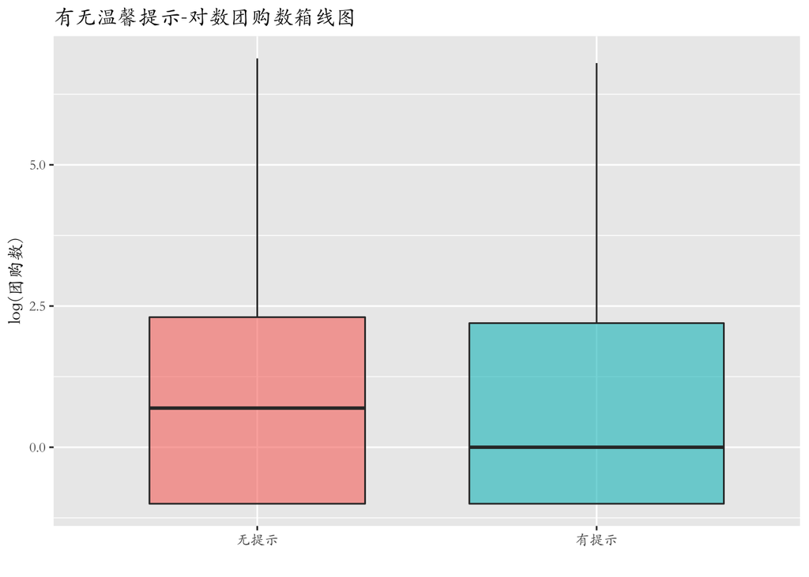

```r
# 建立tips变量，对tuangou1进行是否有温馨提示的分类
tips = rep('无提示', length(tuangou1$标题))
tips[tuangou1$是否有温馨提示 == 1] = '有提示'
ggplot(data = tuangou1, mapping = aes(x = tips, y = tgs_log, fill = tips)) +
  geom_boxplot(alpha = 0.6, varwidth = T) +
  labs(x = ' ', y = 'log(团购数)', title = '有无温馨提示-对数团购数箱线图') +
  theme(text = element_text(family = 'STKaiti')) +
  scale_fill_discrete(guide = FALSE)
```

从箱线图中箱子的位置可以看出其实进行划分以后两类样本的对数团购数差不太多，说明大家其实不是很关心是否有温馨提示，说明消费者更加关注于团购项目本身的内容和质量。

## 赠送礼物

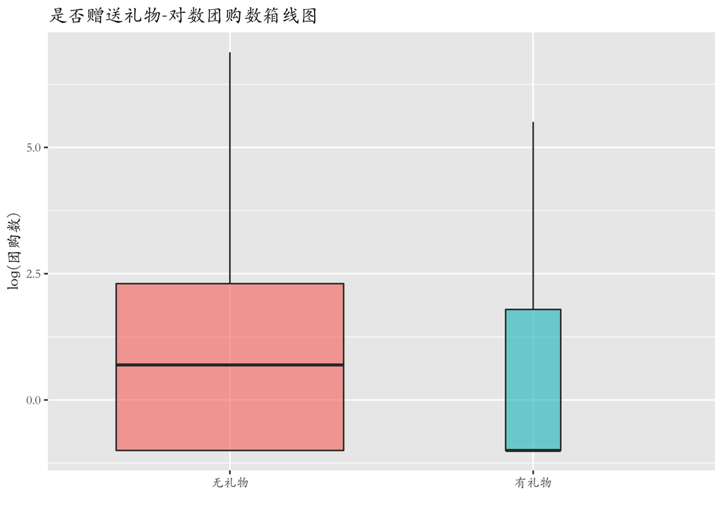

```r
# 建立gift变量，对tuangou1进行是否赠送礼物的分类
gift = rep('无礼物', length(tuangou1$标题))
gift[tuangou1$有礼品 == 1] = '有礼物'
ggplot(data = tuangou1, mapping = aes(x = gift, y = tgs_log, fill = gift)) +
  geom_boxplot(alpha = 0.6, varwidth = T) +
  labs(x = ' ', y = 'log(团购数)', title = '是否赠送礼物-对数团购数箱线图') +
  theme(text = element_text(family = 'STKaiti')) +
  scale_fill_discrete(guide = FALSE)
```

## 是否仅限本人

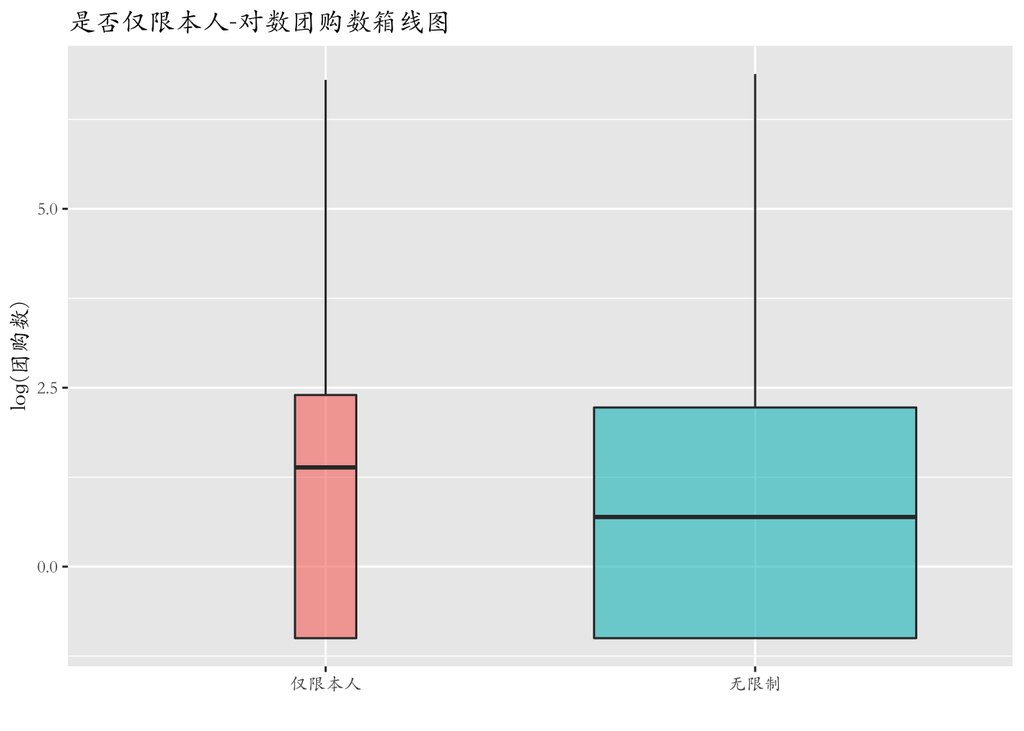

```r
# 建立lim变量，对tuangou1进行是否仅限本人的分类
lim = rep('无限制', length(tuangou1$标题))
lim[tuangou1$仅限本人 == 1] = '仅限本人'
ggplot(data = tuangou1, mapping = aes(x = lim, y = tgs_log, fill = lim)) +
  geom_boxplot(alpha = 0.6, varwidth = T) +
  labs(x = ' ', y = 'log(团购数)', title = '是否仅限本人-对数团购数箱线图') +
  theme(text = element_text(family = 'STKaiti')) +
  scale_fill_discrete(guide = FALSE)
```

相差也不大，但是仅限本人还稍微高一点（不太符合预期），但是相对来说以上两个变量划分后的两个集合样本数相差较大，可能不是很具有代表性，一种可能的解释：因为多数消费者都是为了自己购买，设置了“仅限本人”的项目可能说明了该团购项目设计比较严谨认真，反映了项目质量较高，所以更能吸引消费者。

## 是否是体验活动

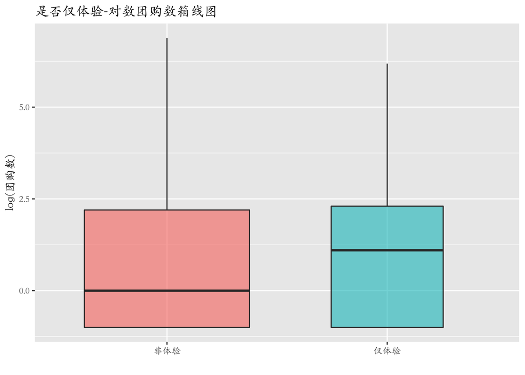

```r
# 建立try变量，对tuangou1进行是否是体验活动的分类
try = rep('非体验', length(tuangou1$标题))
try[tuangou1$仅体验 == 1] = '仅体验'
ggplot(data = tuangou1, mapping = aes(x = try, y = tgs_log, fill = try)) +
  geom_boxplot(alpha = 0.6, varwidth = T) +
  labs(x = ' ', y = 'log(团购数)', title = '是否仅体验-对数团购数箱线图') +
  theme(text = element_text(family = 'STKaiti')) +
  scale_fill_discrete(guide = FALSE)
```

体验活动的受欢迎程度相对较高一些，可能是因为大家团购一般都是因为想要第一次去试试，所以体验的选择很多，如果要长期参加的话可能不会选择团购而是去实体店里办卡之类的。

```r
# 构造以下四个项目以及其他项目的哑变量
tuangou1$"瑜伽"  <- 0
tuangou1$"桌球"  <- 0
tuangou1$"舞蹈"  <- 0
tuangou1$"健身"  <- 0
tuangou1$"其他"  <- 0
tuangou1$瑜伽[tuangou1$项目 == "瑜伽"] <- 1
tuangou1$桌球[tuangou1$项目 == "桌球"] <- 1
tuangou1$舞蹈[tuangou1$项目 == "舞蹈"] <- 1
tuangou1$健身[tuangou1$项目 == "健身"] <- 1
tuangou1$其他[tuangou1$项目 == "其他"] <- 1
```